# Bike Sharing Data Analysis Notebook

N Plaunov

## Business task

#### Recommendations, based on discovered facts

- **Limit duration of a single ride for non-members**, without affecting members trips duration
- Minimize impact of such policy change by **carefully choosing duration limit**  
  *Suggestion: set maximum duration of the trip for casual riders at or about average time they spend on a trip*
- Considering that there is a small number of bike station, preferred by casual riders, **organize campaign** in the vicinity of those stations, explaining advantages of the annual subscription
- Aforementioned changes should create conditions that make membership more attractive

#### *Technical details of the data analysis could be found below*

```r
library("tidyverse")
library("hms")
library("sf")
library("mapview")
```

#### Preparing Environment and Loading Data

##### *Loading and Normalizing Data Across Two Data Sources*

- Reading data from CSVs …

```r
df_bike_trips_2019 <- read.csv("Divvy_Trips_2019_Q1.csv")
df_bike_trips_2020 <- read.csv("Divvy_Trips_2020_Q1.csv")
```

```r
# Storing stations' locations for the future, using 2020 data
df_station_loc <- df_bike_trips_2020 %>% distinct(start_station_id, start_lat, start_lng)
```

- Changing column names to match between two data sources …

```r
# Renaming columns of 2019 data intop 2020 forma. Use only columns that exist in 2020 dataset
df_2019 <- df_bike_trips_2019 %>%
  select(trip_id, start_time, end_time, from_station_id, to_station_id, from_station_name, to_station_name, usertype) %>%
  rename("ride_id"="trip_id") %>% rename("started_at"="start_time") %>%
  rename("ended_at"="end_time") %>% rename("start_station_id"="from_station_id") %>%
  rename("end_station_id"="to_station_id") %>% rename("start_station_name"="from_station_name") %>%
  rename("end_station_name"="to_station_name") %>% rename("member_casual"="usertype")
```

```r
# Changing values in 2019 data for member_casual to match 2020 names
df_2019["member_casual"][df_2019["member_casual"] == "Subscriber"] <- "member"
df_2019["member_casual"][df_2019["member_casual"] == "Customer"] <- "casual"
```

```r
# Droping columns from 2020 dataset that do not exist in 2019 one
df_2020 <- df_bike_trips_2020 %>%
  select(ride_id, started_at, ended_at, start_station_id, end_station_id, start_station_name, end_station_name, member_casual)

# Clean up to free up some RAM
rm(df_bike_trips_2019)
rm(df_bike_trips_2020)
```

- Merging data from two data sources …

```r
# Merging two dataframes, brought to the same format
df_2019_2020 <- rbind(df_2019, df_2020)

# Clean up to free up some RAM
rm(df_2019)
rm(df_2020)
```

- Adding calculated columns for summaries …

```r
# Creating columns to calculate trips duration and days of week those were ridden
df_2019_2020$ride_dur <- with(df_2019_2020, as.numeric(difftime(ended_at, started_at)))
df_2019_2020$day_of_week <- with(df_2019_2020, strftime(df_2019_2020$started_at, "%A"))
```

#### *Performing Data Cleanup and Preparing Data for Graphs*

- Removing trips that have negative duration …

```r
# Removing trips whose duration is negative
df_tmp <- df_2019_2020[df_2019_2020$ride_dur > 0., ] %>% drop_na()
rm(df_2019_2020)
df_2019_2020 <- df_tmp
rm(df_tmp)
```

- Removing trips that last more than 1 day …

```r
# Removing trips that are longer than 1 day
df_tmp <- df_2019_2020[df_2019_2020$ride_dur < 86401., ] %>% drop_na()
rm(df_2019_2020)
df_2019_2020 <- df_tmp
rm(df_tmp)
```

- Grouping and summarizing data to use in graphs …

```r
# Checking and preparing to graph distribution of the data
df_summ <- df_2019_2020 %>% group_by(day_of_week,member_casual) %>%
  summarize(mean_ride_dur = mean(ride_dur),
            max_ride_dur = max(ride_dur),
            min_ride_dur = min(ride_dur),
            total_rides = n(),
            rides_dur = sum(ride_dur))
# Creating levels for days of the week for sorting
df_summ$day_of_week <- factor(df_summ$day_of_week, levels = c("Sunday", "Monday",
                                                              "Tuesday", "Wednesday",
                                                              "Thursday", "Friday",
                                                              "Saturday"))
# Sorting weekdays according to levels
df_summ_sorted <- df_summ[order(df_summ$day_of_week), ]

rm(df_summ)
```

#### *Presenting Data Facts*

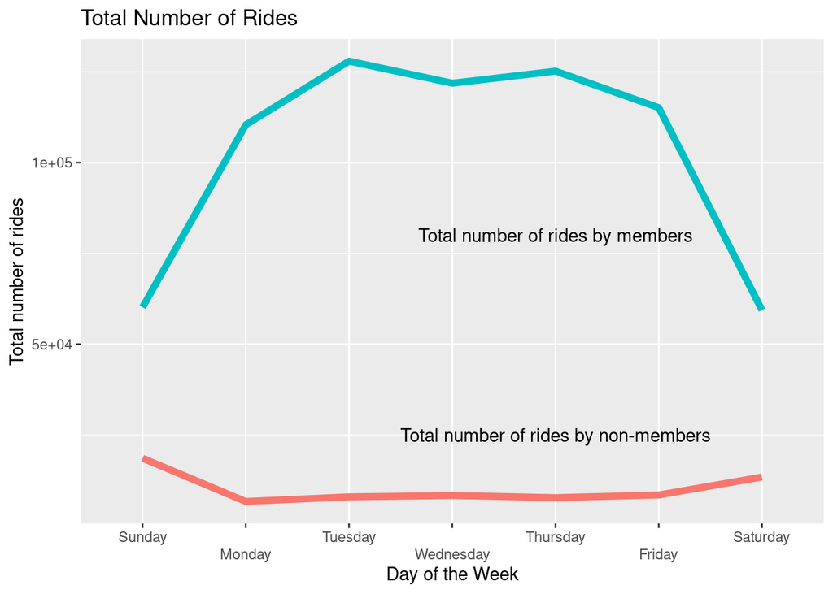

```r
# Displaying total number of rides per day of the week and per rider category
ggplot(data=df_summ_sorted)+geom_line(mapping=aes(x=day_of_week,
                                           y=total_rides,
                                           color=member_casual,
                                           group=member_casual),linewidth=2)+
  labs(x="Day of the Week", y="Total number of rides",title="Total Number of Rides")+
  annotate(geom="text",x="Thursday",y=80000,label="Total number of rides by members")+
  annotate(geom="text",x="Thursday",y=25000,label="Total number of rides by non-members")+
  guides(x=guide_axis(n.dodge = 2,check.overlap = TRUE))+
  theme(legend.position = "none")
```

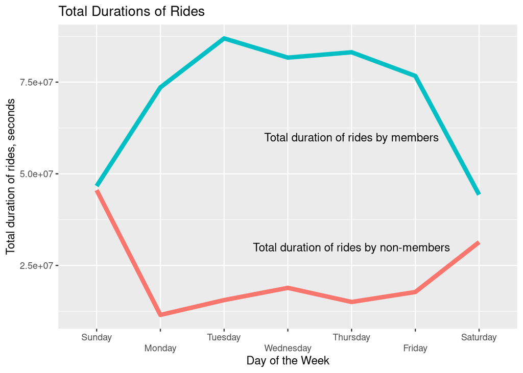

```r
# Displaying rides duration per day of the week and per rider category
ggplot(data=df_summ_sorted)+geom_line(mapping=aes(x=day_of_week,
                                           y=rides_dur,
                                           color=member_casual,
                                           group=member_casual),linewidth=2)+
  labs(x="Day of the Week", y="Total duration of rides, seconds",title="Total Durations of Rides")+
  annotate(geom="text",x="Thursday",y=6e+07,label="Total duration of rides by members")+
  annotate(geom="text",x="Thursday",y=3e+07,label="Total duration of rides by non-members")+
  guides(x=guide_axis(n.dodge = 2,check.overlap = TRUE))+
  theme(legend.position = "none")
```

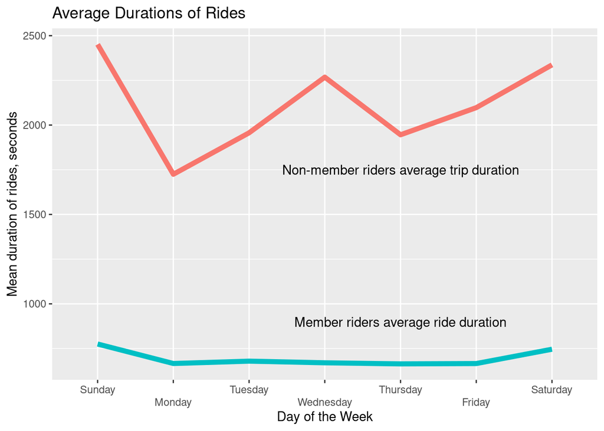

```r
# Displaying average ride duration for members and casual riders
ggplot(data=df_summ_sorted)+geom_line(mapping=aes(x=day_of_week,
                                           y=mean_ride_dur,
                                           color=member_casual,
                                           group=member_casual),linewidth=2)+
  labs(x="Day of the Week", y="Mean duration of rides, seconds",title="Average Durations of Rides")+
  annotate(geom="text",x="Thursday",y=900,label="Member riders average ride duration")+
  annotate(geom="text",x="Thursday",y=1750,label="Non-member riders average trip duration")+
  guides(x=guide_axis(n.dodge = 2,check.overlap = TRUE))+
  theme(legend.position = "none")
```

As data for the year of 2020 includes latitude and longitude of each bike station, I used that data to extrapolate to the year of 2019 that allowed me to create maps of the most popular stations for subscribed and non-subscribed travelers.

```r
rm(df_summ_sorted)

# Preparing data for maps
df_member_stations <- df_2019_2020[df_2019_2020$member_casual == "member", ] %>% distinct(start_station_name, start_station_id)
df_casual_stations <- df_2019_2020[df_2019_2020$member_casual == "casual", ] %>% distinct(start_station_name, start_station_id)


# Merging stations that are used by casual riders with stations' locations
df_casual_st_loc <- merge(x = df_casual_stations, y = df_station_loc, by = "start_station_id", all = TRUE)
rm(df_casual_stations)

# Merging stations that are used by member riders with stations' locations
df_member_st_loc <- merge(x = df_member_stations, y = df_station_loc, by = "start_station_id", all = TRUE)
rm(df_member_stations)
rm(df_station_loc)

# Calculating number of rides per riders' category; stations are sorted by number of rides
df_num_rides_member <- df_2019_2020[df_2019_2020$member_casual == "member", ] %>% count(start_station_id, sort=TRUE, name = "number_of_rides")
df_num_rides_casual <- df_2019_2020[df_2019_2020$member_casual == "casual", ] %>% count(start_station_id, sort=TRUE, name = "number_of_rides")

rm(df_2019_2020)

# Merging stations' locations with number of rides from them per riders' category
df_member_full <- merge(x = df_member_st_loc, y = df_num_rides_member, by = "start_station_id", all = TRUE) %>% drop_na()
df_casual_full <- merge(x = df_casual_st_loc, y = df_num_rides_casual, by = "start_station_id", all = TRUE) %>% drop_na()

rm(df_num_rides_member)
rm(df_num_rides_casual)
rm(df_member_st_loc)
rm(df_casual_st_loc)

# Generating dataframe for results summary
df_show <- df_casual_full %>% arrange(desc(number_of_rides)) %>% top_n(10) %>%
  subset(select = -c(1,3,4)) %>% rename("Station Name      "="start_station_name") %>%
  rename("Number of Rides"="number_of_rides")


# By converting dataframe into the spatial object, Mapview can be customized:
casual_sf <- st_as_sf(df_casual_full, coords = c("start_lng", "start_lat"), crs = 4326)
member_sf <- st_as_sf(df_member_full, coords = c("start_lng", "start_lat"), crs = 4326)

rm(df_casual_full)
rm(df_member_full)

# Creating palette for maps
pal = mapviewPalette("mapviewSpectralColors")
```

#### Map of the trips starting stations for **casual** riders

```r
# Creating map of bike station, from which casual riders start their trips
mapview(casual_sf["number_of_rides"],
        cex = casual_sf$number_of_rides/200,
        legend = TRUE,
        col.regions = pal(200),
        layer.name = "number_of_rides")
```

[interactive chart not shown]

```r
rm(casual_sf)
```

#### Map of the trips starting stations for **member** riders

```r
# Creating map of starting stations for members
mapview(member_sf["number_of_rides"],
        cex = member_sf$number_of_rides/200,
        legend = TRUE,
        col.regions = pal(200),
        layer.name = "number_of_rides")
```

[interactive chart not shown]

```r
rm(member_sf)
rm(pal)
```

### Detailed Recommendations

Considering that casual riders are spending so much time on the bikes and probably are not forced in any way to shorten those rides, it seems reasonable to **create conditions, limiting casual bike trips**, especially during weekends, while members could continue using bikes for as long as they need. Creating such inconvenience for the casual riders should create additional argument for them to consider buying membership. **To avoid significant dissatisfaction by the trip time shortening**, it could be recommended to **set such limit close to their average ride lengths** (i.e., ~2000 seconds or 33:20 minutes.)

As could be seen from two previous maps, **casual riders prefer a handful of stations** to start their trips, while bike sharing members usually use bikes to commute to the jobs that are distributed around the city. Based on this information, it could be suggested to **create membership promotional campaign in vicinity of the bike stations, preferred by casual riders**, explaining new rules and advantages to become members.

##### *Bike Staions, Favored by the Casual Riders*

```r
writeLines("td, th { padding : 6px } th { background-color : black ; color : white; border : 1px solid black; } td { color : black ; border : 1px solid black }", con = "mystyle.css")
knitr::kable(df_show, format = "html")
```

| Station Name | Number of Rides |
| --- | --- |
| HQ QR | 3556 |
| Streeter Dr & Grand Ave | 2741 |
| Lake Shore Dr & Monroe St | 2727 |
| Shedd Aquarium | 1831 |
| Millennium Park | 1403 |
| Michigan Ave & Oak St | 1017 |
| Michigan Ave & Washington St | 835 |
| Dusable Harbor | 829 |
| Adler Planetarium | 826 |
| Theater on the Lake | 794 |

```r
rm(df_show)
```